# **Single cell data IO in R**

## **library**

```r
# options(warn = -1)
library(Seurat)
library(SingleCellExperiment)
library(hdf5r)
library(RIOH5)
library(scater)
```

## **1. Reading Seurat data from R rds file**

### **1.1 The data was read by `.rds` file for seurat**

This data is the "Seurat" object， which contains**counts matrix** , **log-normal matrix**, **scale data**, **cell annotation**, **gene annotation**, **dimension reduction** and **cell-cell similarity matrix**.See the table below.

| data type | seurat solt | Note |
| --- | --- | --- |
| coutnts matrix | `data@assays$RNA@counts` |  |
| log-normal data | `data@assays$RNA@data` |  |
| scale data | `data@assays$RNA@scale.data` | not saved |
| cell annotation | `data@meta.data` |  |
| gene annotation | `data@assays$RNA@meta.features` |  |
| dimension reduction | `data@reductions` |  |
| cell-cell similarty matrix | `data@assays$RNA@meta.features` | not saved |

```r
data = readRDS('./seurat.rds')
```

```r
class(data)
data
```

'Seurat'

```
An object of class Seurat
19037 features across 806 samples within 1 assay
Active assay: RNA (19037 features)
 2 dimensional reductions calculated: pca, umap
```

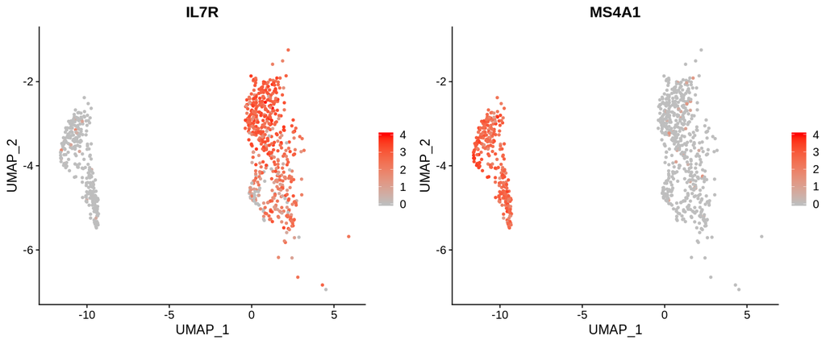

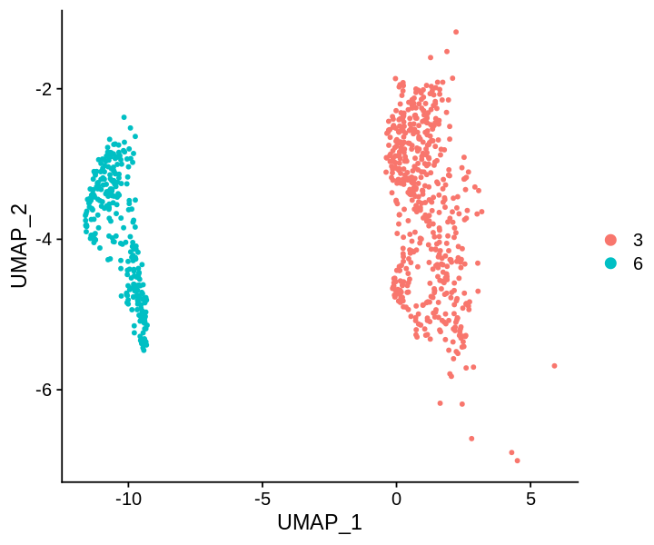

```r
# check data fidelity
options(repr.plot.width=12, repr.plot.height=5)
FeaturePlot(data, features = c('IL7R','MS4A1'), ncol = 2, cols = c('grey', 'red'))
options(repr.plot.width=6, repr.plot.height=5)
DimPlot(data, group.by = 'seurat_clusters')
```

### **1.2.The h5 file(seurat) can be saved by calling `write_h5`**

The `data` is the seruat object. Now, we save the our h5 file. we call the function `write_h5` to save the data.This file can be read not only in R, but also in Python. It is important that the data is not affected by downstream analysis. The user needs to set the parameter `object.type` to determine what object are saved. At present, we support saving the object of **Seurat**, **SinglCellExperiment**, **Monocle**. We will continue to add more object compatibility in the future.  
Our software **does not** save **scale data** and **cell-cell similarity matrix** by default. The representations of **cell-cell similarity matrix** are different between R Seurat and Python scanpy, so they are not saved by default.

```r
write_h5(data = data, object.type = 'seurat',file = './seurat_r.h5')
```

### **1.3.The h5 file can be read by calling `read_h5`**

The function `read_h5` provides a conversion of multiple objects in R, which can be convert data into, **Seurat objects**, or **SingleCellExperiment**,or **Monocle objects**. The user can convert an H5 file to a target object by setting the parameter `target.object` .We will continue to add more object compatibility in the future.

#### **to Seurat**

```r
# read the h5 file for seurat object
data_seurat = read_h5(target.object = 'seurat', file = './seurat_r.h5')
```

```r
class(data_seurat)
```

'Seurat'

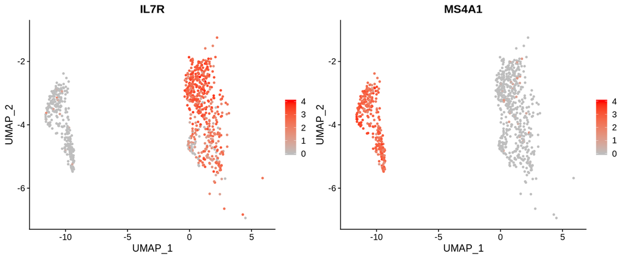

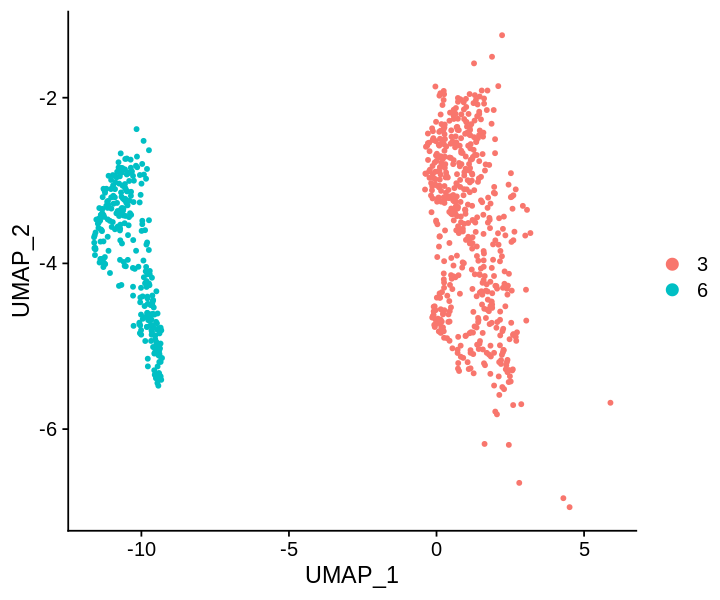

```r
options(repr.plot.width=12, repr.plot.height=5)
FeaturePlot(data_seurat, features = c('IL7R','MS4A1'), ncol = 2, cols = c('grey', 'red'))
options(repr.plot.width=6, repr.plot.height=5)
DimPlot(data_seurat, group.by = 'seurat_clusters')
```

#### **to SinglCellExperiment**

```r
# read the h5 file for singlcellexperiment object
data_sce = read_h5(target.object = 'singlecellexperiment', file = './seurat_r.h5')
```

```r
class(data_sce)
```

'SingleCellExperiment'

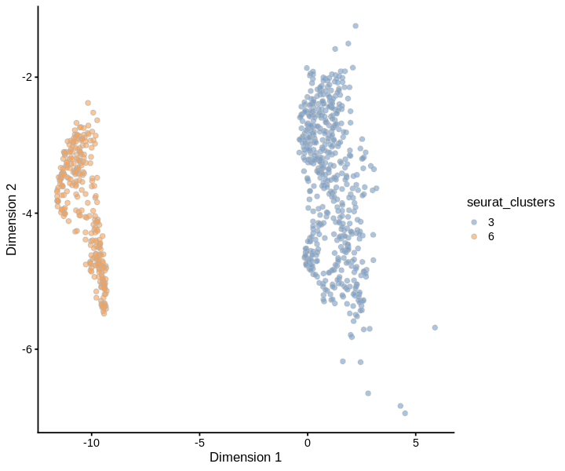

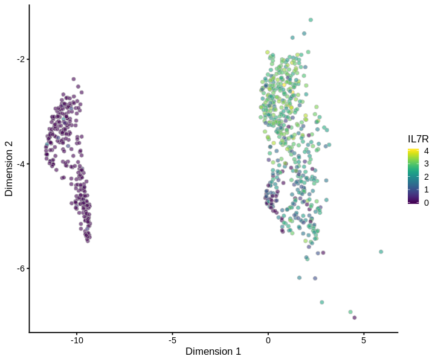

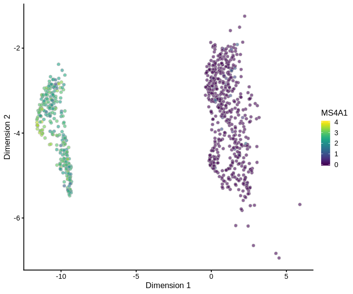

```r
plotReducedDim(data_sce, use_dimred='umap', colour_by = c("seurat_clusters"))
plotReducedDim(data_sce, use_dimred='umap', colour_by = c("IL7R"))
plotReducedDim(data_sce, use_dimred='umap', colour_by = c("MS4A1"))
```

### **1.4 Turn to the PyIOH5 tutorial**

Let's go to the [PyIOH5](https://jiekailab.github.io/scIO/sc_data_IO_python.html) tutorial to see more details.

## **2. Reading SingleCellExperiment data from R rds file**

### **2.1 The data was read by .rds file for SingleCellExperiment**

| data type | SingleCellExperiment | Note |
| --- | --- | --- |
| coutnts matrix | `data@assays$data$counts` |  |
| log-normal data | `data@assays$data$logcounts` |  |
| scale data | NA |  |
| cell annotation | `data@colData` |  |
| gene annotation | `data@rowData` |  |
| dimension reduction | `data@reducedDims` |  |
| cell-cell similarty matrix | NA |  |

```r
data = readRDS('./sce.rds')
```

The current version only supports the `Matrix`-sparse matrix: `dgCMatrix` and the `base`-dense matrix: `matrix`, while other matrix formats may be error-prone.

```r
# In the SingleCellExperiment object, the logcounts is not dgCMatrix. So we change the class by calling `as`
class(logcounts(data))
```

'dgeMatrix'

```r
logcounts(data) = as(logcounts(data), 'dgCMatrix')
class(logcounts(data))
```

'dgCMatrix'

```r
class(data)
data
```

'SingleCellExperiment'

```
class: SingleCellExperiment
dim: 19037 806
metadata(0):
assays(2): counts logcounts
rownames(19037): AL627309.1 AL669831.5 ... AL354822.1 AC240274.1
rowData names(5): vst.mean vst.variance vst.variance.expected
  vst.variance.standardized vst.variable
colnames(806): AAACCCATCTGCCCTA AAACGAAAGCAATTAG ... TTTGGAGTCGAGCTGC
  TTTGTTGCATACAGCT
colData names(6): orig.ident nCount_RNA ... RNA_snn_res.0.4
  seurat_clusters
reducedDimNames(2): PCA TSNE
spikeNames(0):
```

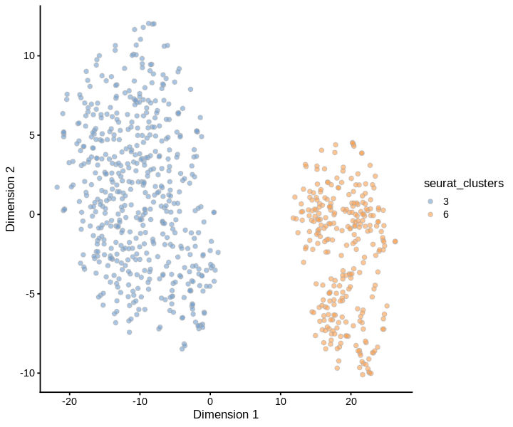

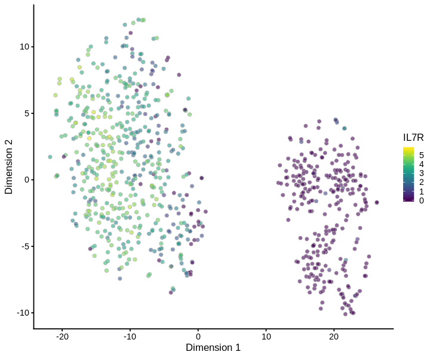

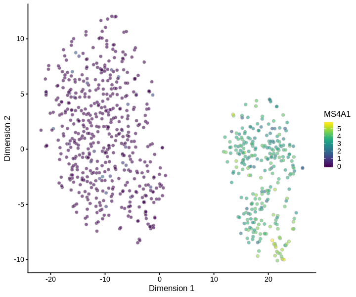

```r
plotReducedDim(data, use_dimred='TSNE', colour_by = c("seurat_clusters"))
plotReducedDim(data, use_dimred='TSNE', colour_by = c("IL7R"))
plotReducedDim(data, use_dimred='TSNE', colour_by = c("MS4A1"))
```

### **2.2.The h5 file(SingleCellExperiment) can be saved by calling `write_h5`**

```r
write_h5(data = data, object.type = 'singlecellexperiment',file = './sce_r.h5')
```

### **2.3. The h5 file can be read by calling `read_h5`**

#### **to Seurat object**

```r
data_seurat = read_h5(target.object = 'seurat', file = './sce_r.h5')
```

```r
data_seurat
```

```
An object of class Seurat
19037 features across 806 samples within 1 assay
Active assay: RNA (19037 features)
 2 dimensional reductions calculated: pca, tsne
```

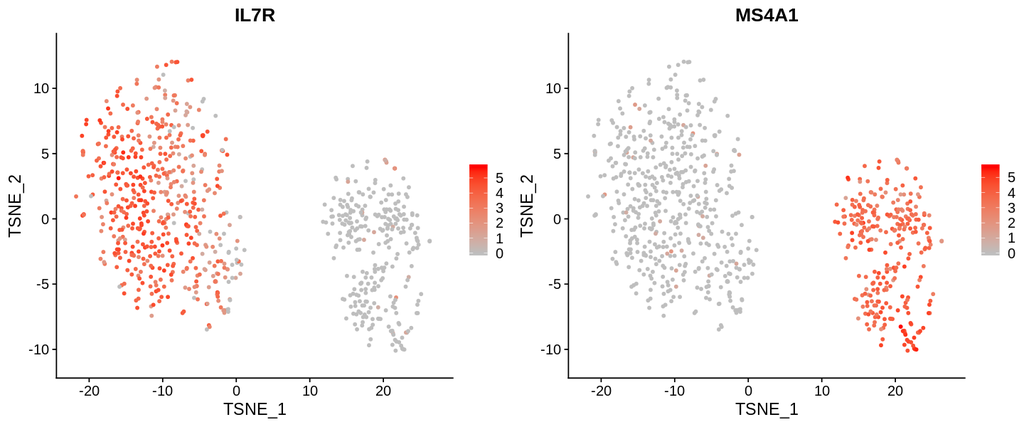

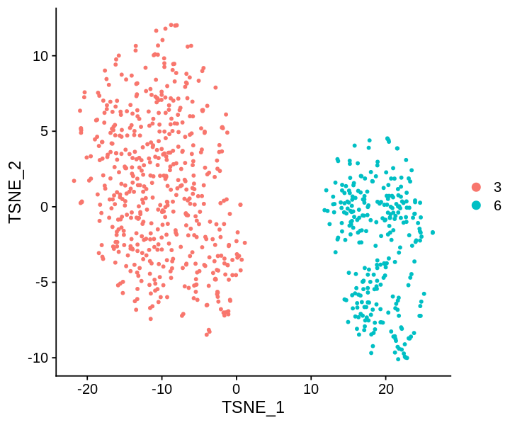

```r
options(repr.plot.width=12, repr.plot.height=5)
FeaturePlot(data_seurat, features = c('IL7R','MS4A1'), ncol = 2, cols = c('grey', 'red'))
options(repr.plot.width=6, repr.plot.height=5)
DimPlot(data_seurat, group.by = 'seurat_clusters')
```

#### **to SingleCellExperiment**

```r
data_sce = read_h5(target.object = 'singlecellexperiment', file = './sce_r.h5')
```

```r
data_sce
```

```
class: SingleCellExperiment
dim: 19037 806
metadata(0):
assays(2): logcounts counts
rownames(19037): AL627309.1 AL669831.5 ... AL354822.1 AC240274.1
rowData names(5): vst.mean vst.variance vst.variance.expected
  vst.variance.standardized vst.variable
colnames(806): AAACCCATCTGCCCTA AAACGAAAGCAATTAG ... TTTGGAGTCGAGCTGC
  TTTGTTGCATACAGCT
colData names(6): orig.ident nCount_RNA ... RNA_snn_res.0.4
  seurat_clusters
reducedDimNames(2): pca tsne
spikeNames(0):
```

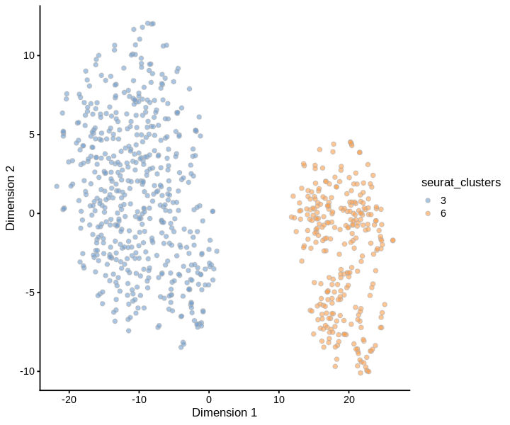

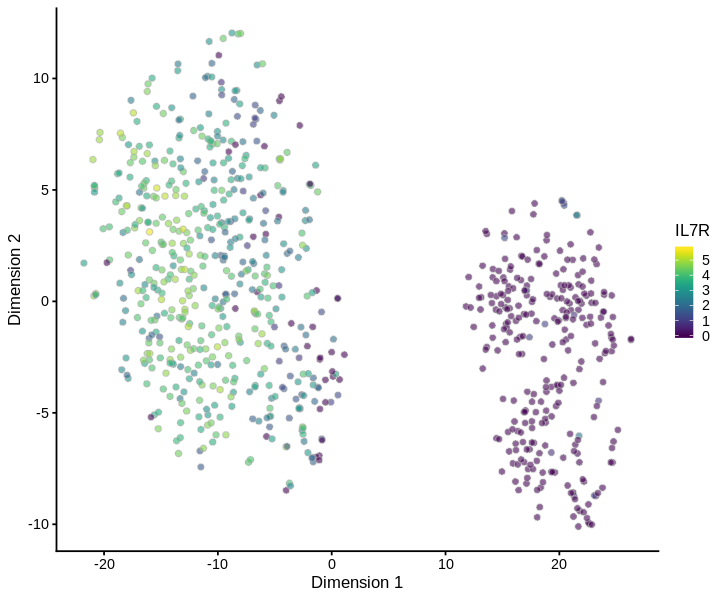

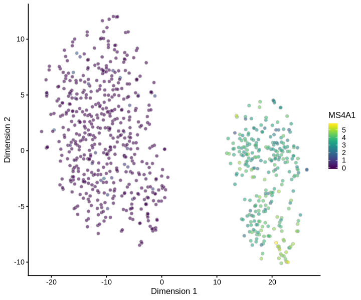

```r
plotReducedDim(data_sce, use_dimred='tsne', colour_by = c("seurat_clusters"))
plotReducedDim(data_sce, use_dimred='tsne', colour_by = c("IL7R"))
plotReducedDim(data_sce, use_dimred='tsne', colour_by = c("MS4A1"))
```

### **2.4 Turn to the PyIOH5 tutorial**

Let's go to the [PyIOH5](https://jiekailab.github.io/scIO/sc_data_IO_python.html) tutorial to see more detials.

## **3. read the h5 file from Pyhton**

#### **to Seurat**

```r
data_seurat = read_h5(target.object = 'seurat', file = './py_scanpy.h5')
```

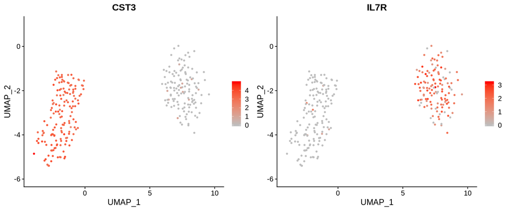

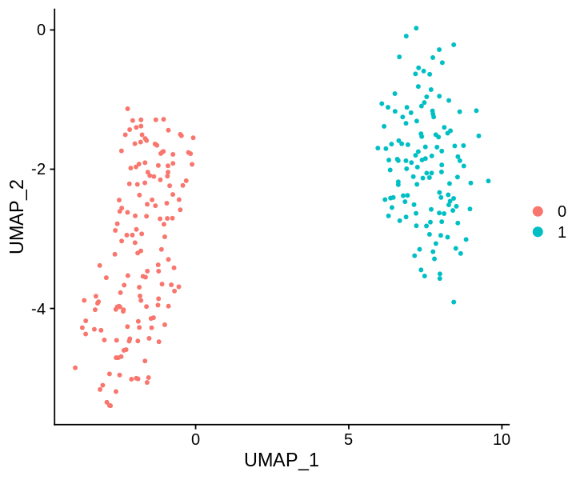

```r
options(repr.plot.width=12, repr.plot.height=5)
FeaturePlot(data_seurat, features = c('CST3','IL7R'), ncol = 2, cols = c('grey', 'red'))
options(repr.plot.width=6, repr.plot.height=5)
DimPlot(data_seurat, group.by = 'leiden')
```

#### **to SingleCellExperiment**

```r
data_sce = read_h5(target.object = 'singlecellexperiment', file = './py_scanpy.h5')
```

```r
data_sce
```

```
class: SingleCellExperiment
dim: 19037 278
metadata(0):
assays(1): counts
rownames(19037): AL627309.1 AL669831.5 ... AL354822.1 AC240274.1
rowData names(12): gene_ids feature_types ... dispersions
  dispersions_norm
colnames(278): AAACGAACAGAAGTTA-1 AAAGAACAGGCATGGT-1 ...
  TTTCCTCTCATGTCTT-1 TTTGGTTCAAAGTATG-1
colData names(6): n_genes n_genes_by_counts ... pct_counts_mt leiden
reducedDimNames(2): pca umap
spikeNames(0):
```

```r
logcounts(data_sce) = counts(data_sce)
```

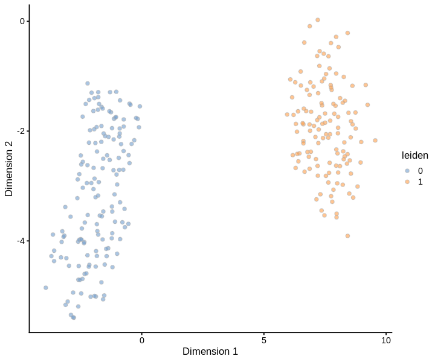

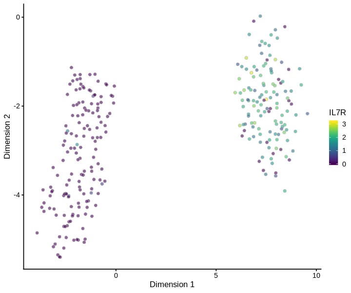

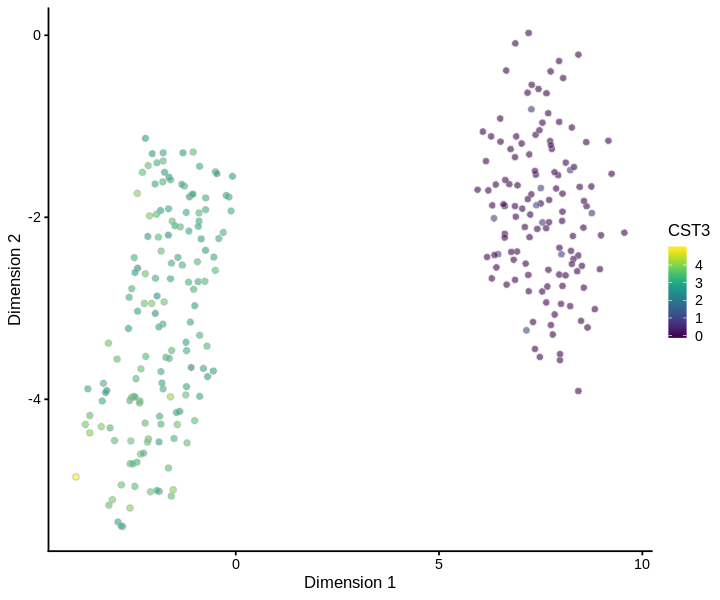

```r
plotReducedDim(data_sce, use_dimred='umap', colour_by = c("leiden"))
plotReducedDim(data_sce, use_dimred='umap', colour_by = c("IL7R") ,)
plotReducedDim(data_sce, use_dimred='umap', colour_by = c("CST3"))
```